# INFSCI 2595 Fall 2025 - MIDTERM

Assigned October 9, 2025; Due: October 15, 2025

Surya Tej Boddu

Submission time: Octover 15, 2025 at 11:59PM EST

#### Collaborators

You are **NOT** allowed to collaborate within anyone. Collaboration, copying, and/or cheating of any kind will not be tolerated.

By downloading the template file you assert that you will **not** collaborate with anyone else on this exam.

## Overview

This midterm tests your understanding of the concepts, math, and programming required to learn distributions from data. You are required to perform a mixture of derivations and programming to solve the questions on the exam.

**READ the problem statements CAREFULLY!**

**IMPORTANT**: The RMarkdown assumes you have downloaded two data sets (CSV files) and saved them to the same directory you saved the template Rmarkdown file. If you do not have the CSV files in the correct location, the data will not be loaded correctly.

### IMPORTANT!!!

Certain code chunks are created for you. Each code chunk has `eval=FALSE` set in the chunk options. You **MUST** change it to be `eval=TRUE` in order for the code chunks to be evaluated when rendering the document.

You are free to add more code chunks if you would like.

## Load packages

This assignment will use packages from the `tidyverse` suite.

```r
library(tidyverse)
```

## Problem 01

You have fit discrete and continuous distributions to data, using non-Bayesian and Bayesian approaches. Bayesian analyses require a prior to be formulated, and it can be difficult to understand how a prior is specified in a general setting. This exam seeks to give you some practice doing that by using the **Empirical Bayes** approach. Empirical Bayes is a rather odd sounding name, but the idea is that you will estimate the parameters of the prior using all of the available data. It is useful when the data can be structured into **groups**. Some groups might have many observations, while others may have a limited number of samples. Empirical Bayes is useful when there are many groups (potentially in the thousands) that can be used to estimate the prior parameters. Once estimated, the prior is applied to each group separately. In this manner you have made use of data to understand the relevant bounds on your unknowns and specified those bounds within a prior probability distribution. The *informative* prior is updated based on each group’s data to yield the updated belief (the posterior) for each group. (Note that if we would have very few groups we could not use Empirical Bayes and thus would need to use full Bayesian approaches via multilevel, hierarchical, or partial pooling models.)

To see how the Empirical Bayes process works you will work with a Sports related application. You are interested in learning the catch probability (or catch rate) in the National Football League (NFL). The catch rate is defined as the number of successful receptions (catches) by a player divided by the number of targets (a target corresponds to a pass thrown at the player). You can therefore consider successfully catching a pass as the **event**, and the number of times the player was targeted as the number of **trials**. The probability of catching a pass is therefore the **event probability** we are interested in learning.

Let’s consider you are working on this application because you were recently hired as a sports analytics intern for an NFL team. You are provided with 3 seasons worth of data (2018, 2019, and 2020) of every player with at least 1 target (thus at least 1 trial). Calculating the catch rate is simple to do. It is also easy to search for and find. For example, [here](https://www.pro-football-reference.com/years/2024/receiving.htm) are the catch rates for all NFL players in the 2024 season. You were hired because the NFL team wishes to move away from simple *point estimates*. The team wants to have a better understanding of the **uncertainty** in the performance. Understanding the uncertainty is critical when evaluating talent, and making decisions for which players to sign in free agency.

You will work with two datasets for this exam. Both are loaded for you in code chunk below. The first, `df_all`, is the larger of the two. The second, `df_focus`, is a subset of `df_all` so that we way can focus on 23 players to help with visualization and discussion in the exam.

```r
file_with_all <- "midterm_all_data.csv"
df_all <- readr::read_csv(file_with_all, col_names = TRUE)
file_with_focus <- "midterm_focus_data.csv"
df_focus <- readr::read_csv(file_with_focus, col_names = TRUE)
```

Both data sets consist of 3 variables, `player_id`, `num_events`, and `num_trials`. The `num_events` is the number of receptions, and `num_trials` is the number of targets. The variables are written in the general terms that we have used in the class rather than NFL specific terms. The `player_id` variable is an ID variable for each player. Thus, one row in either data set tells us the number of receptions and number of targets associated with an individual player over the three seasons. The data in this exam are real and were downloaded from the `nflfastR` package (documentation available [here](https://www.nflfastr.com/index.html) if you are interested). The `player_id` variable is an anonymous identification number I created so that NFL fans cannot easily identify players.

### 1a)

You will eventually use the Empirical Bayes approach in this exam. However, to help motivate why such an approach is useful you will begin by assuming you are not capable of creating an informative prior. For example, even if you watch every Pittsburgh Steelers’ game, you might not know what the average catch rate is in the NFL. Since you do not feel comfortable specifying reasonable bounds, you decide to use a vague and uninformative prior formulation.

You will use a Binomial likelihood and a conjugate Beta prior on the unknown catch rate (or event probability in general terms), $\mu$. For generality, you will denote each player with a subscript $j$ and the total number of players as $J$. Thus, the unknown event probability for the $j$-th player is $\mu_j$ where $j=1,...,J$. The posterior distribution on the $j$-th player’s unknown catch rate, $\mu_j$ given the $m_j$ catches (events) out of $N_j$ targets (trials) is proportional to:

$$p\left(\mu_j \mid \left( m, N \right)_j \right) \propto
\mathrm{Binomial}\left(m_j \mid \mu_j, N_j\right) \times \mathrm{Beta}
\left( \mu_j \mid a, b\right)$$

Notice that in the above posterior formulation, each player has a potentially distinct event probability, $\mu_j$. The prior consists of two shape hyperparameters, $a$ and $b$. The **SAME** prior shape parameters are applied to every player.

**You will assume prior shape parameters of $a=0.5$ and $b=0.5$. How many “prior trials” or “prior targets” does this specification correspond to? Why do you think it represents being “uninformed” about the process?**

#### SOLUTION

What do you think?  
The prior specification of a=0.5 and b=0.5 corresponds to one total prior trial, calculated as the sum of the shape parameters (a + b). This is considered “uninformed” because a weight of only one trial is statistically minimal compared to the observed data, ensuring that the likelihood quickly dominates the posterior. This is the Jeffreys prior, a standard default choice that does not depend on how we choose to measure or express the parameter. This makes it a standard choice in Bayesian analysis when no specific domain knowledge is available to justify a more informative prior.

### 1b)

You are using a conjugate prior to the Binomial likelihood, for each player.

**What type of distribution is the posterior for the unknown event probability, $\mu_j$, for each player, $j=1,...,J$?**

#### SOLUTION

What do you think?  
Based on the use of a Binomial likelihood and a conjugate Beta prior, the posterior distribution for the unknown event probability, $\mu_j$, is a Beta distribution.In Bayesian analysis, the Beta distribution is the conjugate prior for the Binomial likelihood. This means that when we multiply the Binomial likelihood (representing the observed catches and targets) by a Beta prior, the resulting posterior distribution mathematically remains within the Beta family. This conjugacy allows us to update our beliefs about a player’s catch rate simply by adding the observed data to the prior shape parameters.

### 1c)

**Write out the formula for the updated or posterior shape parameters, $a_{new,j}$ and $b_{new,j}$, based on each player’s observed number of catches $m_j$ and observed number of targets $N_j$, as well as the prior shape parameters, $a$ and $b$.**

You do not have to derive the formula for these updated parameters. You may simply write their formula below.

#### SOLUTION

Add your equation blocks here.
$$a_{new,j} = a + m_j$$

$$b_{new,j} = b + (N_j - m_j)$$

### 1d)

**What is the mean, 0.05 Quantile, 0.95 Quantile, and middle 90% uncertainty interval on the catch rate (event probability) according to the assumed “uninformed” prior?** You are allowed to use the appropriate R function to calculate the quantile of a distribution.

#### SOLUTION

Add your code chunks here.

```r
a_prior <- 0.5
b_prior <- 0.5

prior_mean <- a_prior / (a_prior + b_prior)
prior_q05  <- qbeta(0.05, a_prior, b_prior)
prior_q95  <- qbeta(0.95, a_prior, b_prior)

tibble::tibble(
  Statistic = c("Mean", "0.05 Quantile", "0.95 Quantile", "90% Interval Width"),
  Value = c(prior_mean, prior_q05, prior_q95, prior_q95 - prior_q05)
)
```

```
## # A tibble: 4 × 2
##   Statistic            Value
##   <chr>                <dbl>
## 1 Mean               0.5
## 2 0.05 Quantile      0.00616
## 3 0.95 Quantile      0.994
## 4 90% Interval Width 0.988
```

### 1e)

**Based on your formula in Problem 1c), calculate the updated shape parameters for the 23 players in the `df_focus` `tibble`. You should add two columns using `mutate()` named `anew` and `bnew`. Assign your result to the `post_df_focus_from_vague` object.**

#### SOLUTION

```r
a_prior <- 0.5
b_prior <- 0.5

post_df_focus_from_vague <- df_focus %>%
  mutate(
    anew = a_prior + num_events,
    bnew = b_prior + (num_trials - num_events)
  )
```

### 1f)

**Calculate the Posterior Mean, Posterior 0.05 Quantile, and the Posterior 0.95 Quantile for each player in `post_df_focus_from_vague`. You should add 3 columns using `mutate()` named `post_avg`, `post_q05`, and `post_q95`. Assign the result to the variable `summary_post_df_focus_from_vague`.**

#### SOLUTION

```r
summary_post_df_focus_from_vague <- post_df_focus_from_vague %>%
  mutate(
    post_avg = anew / (anew + bnew),
    post_q05 = qbeta(0.05, anew, bnew),
    post_q95 = qbeta(0.95, anew, bnew)
  )
```

### 1g)

You will now visualize the posterior summaries for the 23 players associated with the `df_focus` data set. The bold face font below provides specific instructions for visualizing the posterior summaries for this problem. Please read the instructions carefully! That said, you are free to set colors as you wish.

**Pipe `summary_post_df_focus_from_vague` into `ggplot()` and map the `x` aesthetic to `as.factor(player_id)`. You will use the `geom_linerange()` to represent the posterior uncertainty by setting the `ymin` and `ymax` aesthetics to `post_q05` and `post_q95`, respectively. You will display the posterior mean with a `geom_point()` by setting the `y` aesthetic to `post_avg`.**

**Include the maximum likelihood estimate (MLE) on the event probability as an additional `geom_point()` geom by mapping the `y` aesthetic to the correct value, which you must calculate.**

**Are there players with MLEs that are outside the posterior uncertainty interval? Are there players with posterior mean values that are quite close to the MLEs?**

#### SOLUTION

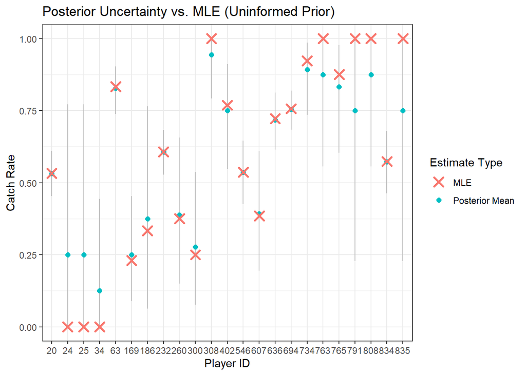

```r
summary_post_df_focus_from_vague %>%
  mutate(mle = num_events / num_trials) %>%
  ggplot(aes(x = as.factor(player_id))) +
  geom_linerange(aes(ymin = post_q05, ymax = post_q95), color = "gray") +
  geom_point(aes(y = post_avg, color = "Posterior Mean"), size = 2) +
  geom_point(aes(y = mle, color = "MLE"), shape = 4, size = 3, stroke = 1.5) +
  labs(x = "Player ID",
       y = "Catch Rate",
       title = "Posterior Uncertainty vs. MLE (Uninformed Prior)",
       color = "Estimate Type") +
  theme_bw()
```

### 1h)

**You will create a similar visualization to that from Problem 1g), except instead of mapping the `x` aesthetic to `as.factor(player_id)` you will map the `x` aesthetic to `as.factor(num_trials)`. You must also map the `group` aesthetic in each geom to the `player_id` variable. Doing so allows you to “dodge” the posterior summaries for each player associated with each `num_trials` value.**

To properly apply the dodging, set the `position` argument to be `position = position_dodge(0.2)` in `geom_linerange()` and both `geom_point()` calls. You should not place `position` inside `aes()`, it should be outside `aes()`.

**Based on your visualization, which players have high posterior uncertainty on the event probability?**

#### SOLUTION

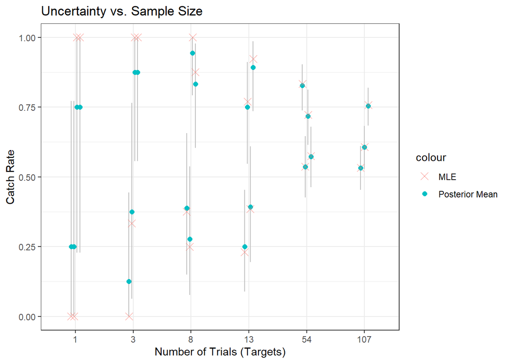

```r
summary_post_df_focus_from_vague %>%
  mutate(mle = num_events / num_trials) %>%
  ggplot(aes(x = as.factor(num_trials), group = player_id)) +
  # Use position_dodge to prevent overlapping points for players with the same trials
  geom_linerange(aes(ymin = post_q05, ymax = post_q95),
                 position = position_dodge(0.2), color = "gray") +
  geom_point(aes(y = post_avg, color = "Posterior Mean"),
             position = position_dodge(0.2), size = 2) +
  geom_point(aes(y = mle, color = "MLE"),
             position = position_dodge(0.2), shape = 4, size = 3) +
  labs(x = "Number of Trials (Targets)",
       y = "Catch Rate",
       title = "Uncertainty vs. Sample Size") +
  theme_bw()
```

What do you think?  
Based on the visualization, the players with the lowest number of trials (the smallest num_trials) exhibit the highest posterior uncertainty. This is visually represented by the longest vertical lines in the plot, indicating a wider 90% uncertainty interval. In a Bayesian framework with an uninformed prior, a small sample size provides less information to the likelihood, resulting in a broader posterior distribution and less certainty about the true catch rate.

### 1i)

You will now calculate the posteriors for **ALL** players based on the uninformed prior. Thus, you will not just the limited number of players in the “focused” data set.

**Calculate the updated shape parameters for all players in the `df_all` `tibble`. You should add two columns using `mutate()` named `anew` and `bnew`. Assign your result to the `post_df_all_from_vague` object.**

#### SOLUTION

Add as many code chunks as you feel are necessary.

```r
a_prior <- 0.5
b_prior <- 0.5

post_df_all_from_vague <- df_all %>%
  mutate(
    anew = a_prior + num_events,
    bnew = b_prior + (num_trials - num_events)
  )
```

### 1j)

**Calculate the Posterior Mean, 0.05 Quantile, and 0.95 Quantile for each player in `post_df_all_from_vague`. You should add 3 columns using `mutate()` named `post_avg`, `post_q05`, and `post_q95`. Assign the result to the variable `summary_post_df_all_from_vague`.**

#### SOLUTION

Add as many code chunks as you feel are necessary.

```r
summary_post_df_all_from_vague <- post_df_all_from_vague %>%
  mutate(
    post_avg = anew / (anew + bnew),
    post_q05 = qbeta(0.05, anew, bnew),
    post_q95 = qbeta(0.95, anew, bnew)
  )
```

### 1k)

You will now visualize the Posterior Mean, based on the uniformative prior, relative to the Maximum Likelihood Estimate for the event probability.

**Create a scatter plot with `ggplot2` where you plot the `post_avg` with respect to the maximum likelihood estimate to the unknown event probability for all players. Map the `color` aesthetic to `num_trials` and include a `geom_abline()` layer with `slope = 1` and `intercept=0`.**

#### SOLUTION

Add as many code chunks as you feel are necessary.

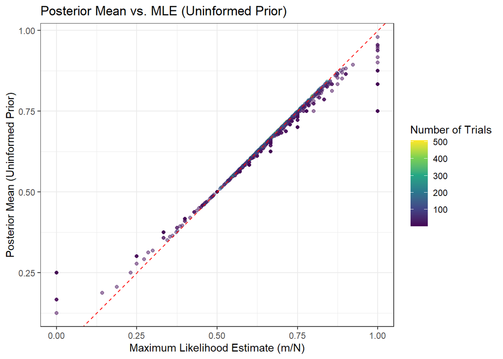

```r
summary_post_df_all_from_vague %>%
  mutate(mle = num_events / num_trials) %>%
  ggplot(aes(x = mle, y = post_avg)) +
  geom_point(aes(color = num_trials), alpha = 0.5) +
  geom_abline(slope = 1, intercept = 0, color = "red", linetype = "dashed") +
  scale_color_viridis_c() +
  labs(x = "Maximum Likelihood Estimate (m/N)",
       y = "Posterior Mean (Uninformed Prior)",
       color = "Number of Trials",
       title = "Posterior Mean vs. MLE (Uninformed Prior)") +
  theme_bw()
```

### 1l)

**Create a scatter plot for the Posterior middle 90% uncertainty interval range (difference between the 0.95 and 0.05 Quantiles) with respect to the `num_trials` using `ggplot2`.**

#### SOLUTION

Add as many code chunks as you feel are necessary.

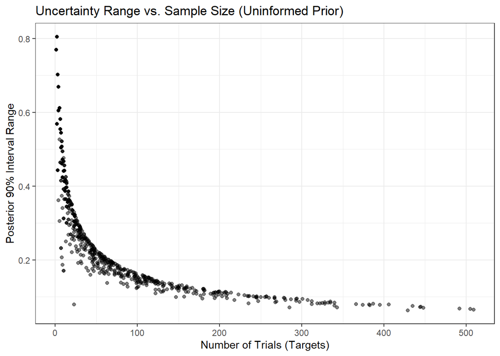

```r
summary_post_df_all_from_vague %>%
  # Calculate the width of the 90% uncertainty interval
  mutate(interval_range = post_q95 - post_q05) %>%
  ggplot(aes(x = num_trials, y = interval_range)) +
  geom_point(alpha = 0.5) +
  labs(x = "Number of Trials (Targets)",
       y = "Posterior 90% Interval Range",
       title = "Uncertainty Range vs. Sample Size (Uninformed Prior)") +
  theme_bw()
```

## Problem 02

In Problem 01, you estimated the unknown event probability for each player separately from all other players. Essentially, you were focused on one player at a time. This style of analysis is known as the **unpooled estimate**, since you are not combining or “pooling” the players (or in general terms the “groups”) together.

The opposite view point is to **completely pool** all players together in order to estimate a single unknown event probability $\mu$. For this, you will assume that all players are independent. Thus the posterior distribution on the unknown “pooled” event probability, $\mu$, is proportional to:

$$p \left( \mu \mid \left( \left(m, N\right)_j \right)_{j=1}^{J} \right)
\propto \prod_{j=1}^{J} \left( \mathrm{Binomial} \left(m_j \mid \mu, N_j
\right) \right) \times \mathrm{Beta} \left(\mu \mid a, b\right)$$

Pay close attention to the subscripts in the above expression. And notice that the prior on the “pooled” unknown $\mu$ relies on the prior shape parameters $a$ and $b$.

### 2a)

**Write out the log-posterior on the pooled unknown $\mu$ up to a normalizing constant in terms of the observations, $m_j$ and $N_j$ for $j=1,...,J$, and the prior shape parameters, $a$ and $b$. Your result should contain a summation series over the $J$ players.**

#### SOLUTION

Add as many equation blocks as you feel are necessary to show the steps to derive the answer.  
To derive the log-posterior $\log(p(\mu \mid \ldots))$, we start with the provided proportionality:

$$p\left(\mu \mid \left((m,N)_j\right)_{j=1}^{J}\right) \propto
\prod_{j=1}^{J} \text{Binomial}(m_j \mid \mu, N_j) \times
\text{Beta}(\mu \mid a, b)$$

Expand the Likelihood and Prior:
$$\prod_{j=1}^{J}\left[\binom{N_j}{m_j}\mu^{m_j}(1-\mu)^{N_j-m_j}\right]
\times \left[\frac{1}{B(a,b)}\mu^{a-1}(1-\mu)^{b-1}\right]$$
Take the Natural Log:
$$\log(p(\mu \mid \ldots)) \propto
\sum_{j=1}^{J}\left[\log\binom{N_j}{m_j} + m_j\log(\mu) +
(N_j-m_j)\log(1-\mu)\right] + \log\left(\frac{1}{B(a,b)}\right) +
(a-1)\log(\mu) + (b-1)\log(1-\mu)$$
Drop Constants (terms not containing $\mu$):

$$\log(p(\mu \mid \ldots)) \propto \sum_{j=1}^{J}\left[m_j\log(\mu) +
(N_j-m_j)\log(1-\mu)\right] + (a-1)\log(\mu) + (b-1)\log(1-\mu)$$
Distribute the Summation:
$$\log(p(\mu \mid \ldots)) \propto \left(\sum_{j=1}^{J}m_j\right)\log(\mu)
+ \left(\sum_{j=1}^{J}(N_j-m_j)\right)\log(1-\mu) + (a-1)\log(\mu) +
(b-1)\log(1-\mu)$$
Final Grouped Form
$$\log\left(p\left(\mu \mid \left((m,N)_j\right)_{j=1}^{J}\right)\right)
\propto \left(\sum_{j=1}^{J}m_j + a - 1\right)\log(\mu) +
\left(\sum_{j=1}^{J}(N_j - m_j) + b - 1\right)\log(1-\mu)$$

### 2b)

The summation series in your solution to 2a) can be simplified by using the average number of events, $\bar{m}$ and the average number of trials $\bar{N}$. The average number of events is defined as:

$$\bar{m} = \frac{1}{J} \sum_{j=1}^{J} \left( m_j \right)$$

and the average number of trials is defined as:

$$\bar{N} = \frac{1}{J} \sum_{j=1}^{J} \left( N_j \right)$$

**Write your result from 2a) in terms of $\bar{m}$, $\bar{N}$, $J$, and the prior shape parameters $a$ and $b$.**

#### SOLUTION

Add as many equation blocks as you feel are necessary to show the steps to derive the answer.
$$\log\left(p\left(\mu \mid \left((m,N)_j\right)_{j=1}^{J}\right)\right)
\propto (J\bar{m} + a - 1)\log(\mu) + (J\bar{N} - J\bar{m} + b -
1)\log(1-\mu)$$
$$\log\left(p\left(\mu \mid \left((m,N)_j\right)_{j=1}^{J}\right)\right)
\propto (J\bar{m} + a - 1)\log(\mu) + (J(\bar{N} - \bar{m}) + b -
1)\log(1-\mu)$$

### 2c)

Your expression in 2b) should look familiar.

**What type of posterior distribution does the unknown “pooled” estimate $\mu$ have?**

**Write out the formulas for the posterior or updated shape parameters for your specified posterior distribution.**

#### SOLUTION

What do you think?  
The unknown “pooled” estimate $\mu$ follows a Beta distribution. This is because the Beta distribution is the conjugate prior for the Binomial likelihood; when we pool all independent trials across the league ($J\bar{N}$) and all successful events ($J\bar{m}$), the mathematical structure of the posterior remains within the Beta family.

Add as many equation blocks as you feel are necessary to show the steps to derive the answer.
$$a_{new} = \sum_{j=1}^{J} m_j + a = J\bar{m} + a$$

$$b_{new} = \sum_{j=1}^{J} (N_j - m_j) + b = J(\bar{N} - \bar{m}) + b$$

### 2d)

**Based on your formula in Problem 2c), calculate the updated shape parameters for the 23 players in the `df_focus` `tibble`. You should add two columns using `mutate()` named `anew` and `bnew`. Assign your result to the `post_df_focus_pooled` object.**

You will still assume an uninformed prior and thus use $a=b=0.5$ as you did in Problem 01. It is important to remember that we are pooling **ALL** players together to learn the pooled estimate, **NOT** just those in the focused set. In other words, your calculations of `anew` and `bnew` should be based off the number of events and trials (`N`,`m`, and `J`) in `df_all`, **not** `df_focus`. You are using the focused set of players right now for visualization purposes.

#### SOLUTION

```r
a_prior <- 0.5
b_prior <- 0.5

M_all <- sum(df_all$num_events)
N_all <- sum(df_all$num_trials)

anew_pooled <- a_prior + M_all
bnew_pooled <- b_prior + (N_all - M_all)

post_df_focus_pooled <- df_focus %>%
  mutate(
    anew = anew_pooled,
    bnew = bnew_pooled
  )
```

### 2e)

**Calculate the Posterior Mean, Posterior 0.05 Quantile, and Posterior 0.95 Quantile for each player in `post_df_focus_pooled`. You should add 3 columns using `mutate()` named `post_avg`, `post_q05`, and `post_q95`. Assign the result to the variable `summary_post_df_focus_pooled`.**

#### SOLUTION

```r
summary_post_df_focus_pooled <- post_df_focus_pooled %>%
  mutate(
    post_avg = anew / (anew + bnew),
    post_q05 = qbeta(0.05, anew, bnew),
    post_q95 = qbeta(0.95, anew, bnew)
  )
```

### 2f)

**Pipe `summary_post_df_focus_pooled` into `ggplot()` and map the `x` aesthetic to `as.factor(player_id)`. You will use the `geom_linerange()` to represent the posterior uncertainty by setting the `ymin` and `ymax` aesthetics to `post_q05` and `post_q95` respectively. You will display the posterior mean with a `geom_point()` by setting the `y` aesthetic to `post_avg`. Include the maximum likelihood estimate (MLE) on the event probability as an additional `geom_point()` geom by mapping the `y` aesthetic to the correct value, which you must calculate. Remember that you are calculating the MLE of the pooled estimate of mu**

**Are there players with MLEs that are outside the posterior uncertainty interval? Are there players with posterior mean values that are quite close to the MLEs?**

#### SOLUTION

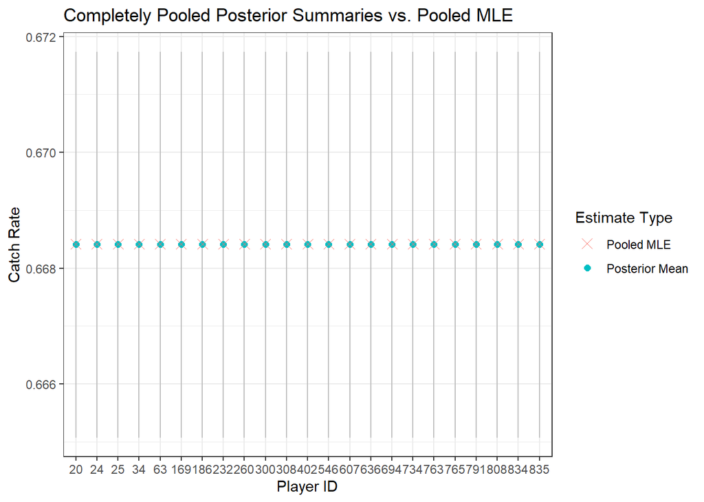

```r
# Calculate the MLE for the entire league (the pooled MLE)
mle_pooled <- sum(df_all$num_events) / sum(df_all$num_trials)

summary_post_df_focus_pooled %>%
  ggplot(aes(x = as.factor(player_id))) +
  geom_linerange(aes(ymin = post_q05, ymax = post_q95), color = "gray") +
  geom_point(aes(y = post_avg, color = "Posterior Mean"), size = 2) +
  geom_point(aes(y = mle_pooled, color = "Pooled MLE"), shape = 4, size = 3) +
  labs(x = "Player ID",
       y = "Catch Rate",
       title = "Completely Pooled Posterior Summaries vs. Pooled MLE",
       color = "Estimate Type") +
  theme_bw()
```

What do you think?  
No players have MLEs outside the posterior uncertainty interval. Because the model pools data from the entire league, the aggregate sample size is massive, which results in an extremely narrow 90% uncertainty interval centered on the global average. So, the posterior mean for every player is identical to the pooled MLE, as the sheer volume of data in the likelihood completely overwhelms the influence of the prior. Furthermore, every player shares the identical posterior distribution and posterior mean, regardless of their individual number of targets or catches, since the pooled model assigns the same $\mu$ to all players.

### 2g)

Your visualization in Problem 2f) should not “feel right”. Something should seem off.

**Why does the “pooled” estimate seem incorrect for this application?**

#### SOLUTION

What do you think?  
The completely pooled estimate assumes that every player has the same unknown catch rate $\mu$. This means regardless of how many targets a player has or how many catches they made, every player receives the identical posterior distribution. A player with 5 targets and 4 catches is treated the same as a player with 200 targets and 160 catches — both get the same posterior mean and uncertainty interval.This is clearly wrong for this application because players genuinely differ in their catching ability. Some receivers are elite pass-catchers while others struggle. Forcing all players to share a single $\mu$ completely ignores individual player talent and performance. In other words, the pooled model has no ability to differentiate between players as it cannot answer the question “who is the best receiver?” because everyone has the same posterior. This makes it useless for talent evaluation purposes.

## Problem 03

You have now worked through two extremes, the **unpooled** and the completely **pooled** estimates on the unknown event probabilities. You will now try to **blend** the two approaches to reach a compromise by using the Empirical Bayes approach.

As stated at the beginning of the document, Empirical Bayes estimates the prior from data. In this setting you are interested in deciding informative values for the prior shape parameters, $a$ and $b$, of the Beta prior on each $\mu_j$. If you have a relevant informative prior you will be able to apply that prior to each player separately (the unpooled approach) while “borrowing strength” from the rest of the data. The Empirical Bayes approach is an approximation to more formal *partial pooling* models where groups with larger sample sizes help estimate parameters associated with small sample size groups. Empirical Bayes is useful when there are hundreds to thousands of separate groups. Estimating the prior shape parameters from many groups allows specifying relevant informative priors without requiring numerous conversations with Subject Matter Experts (SMEs) and allows the data to provide representative bounds.

### 3a)

The Beta prior defines the prior belief on a probability (a fraction or proportion). From an Empirical Bayes approach, you can therefore view the “data” of interest as the observed “catch rate”.

**Plot the histogram of the “catch rate” for all players in the `df_all` data set. Use the `geom_histogram()` geom and set the `binwidth` to be 0.05.**

#### SOLUTION

Add as many code chunks as you feel are necessary.

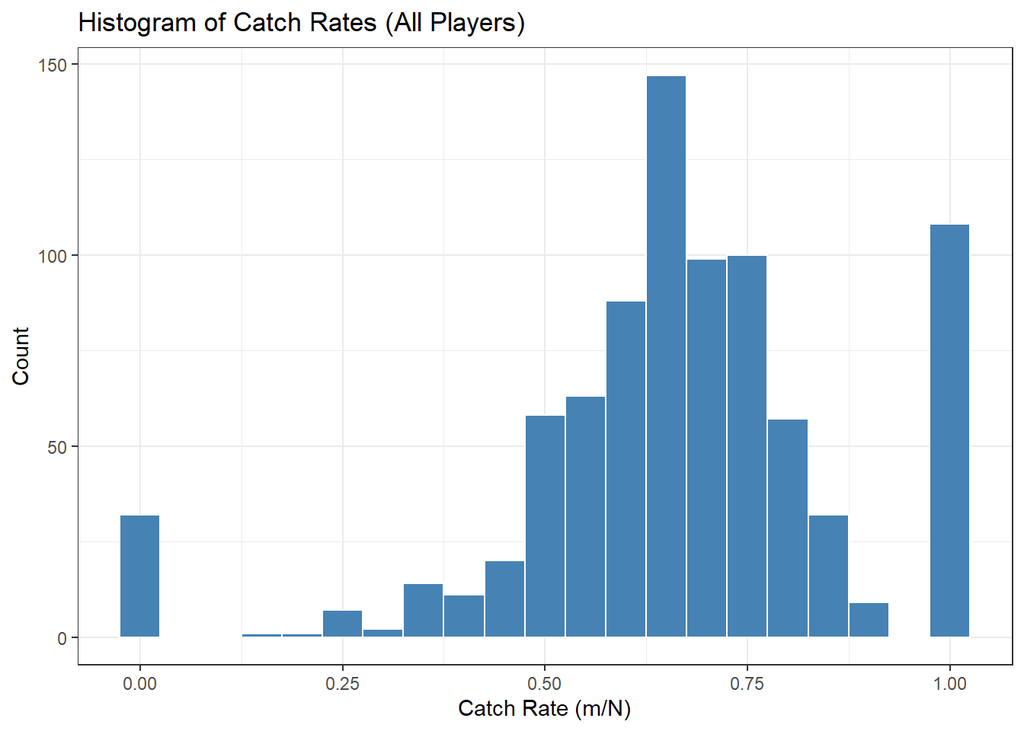

```r
df_all %>%
  mutate(catch_rate = num_events / num_trials) %>%
  ggplot(aes(x = catch_rate)) +
  geom_histogram(binwidth = 0.05, fill = "steelblue", color = "white") +
  labs(x = "Catch Rate (m/N)",
       y = "Count",
       title = "Histogram of Catch Rates (All Players)") +
  theme_bw()
```

### 3b)

**Plot the histogram for all “catch rates” in the `df_all` data set again. However, this time use `facet_wrap()` to break up the visualization into `num_trials > 24`.**

**What can you say about the observations of the players with greater than 25 targets?**

#### SOLUTION

Add as many code chunks as you feel are necessary.

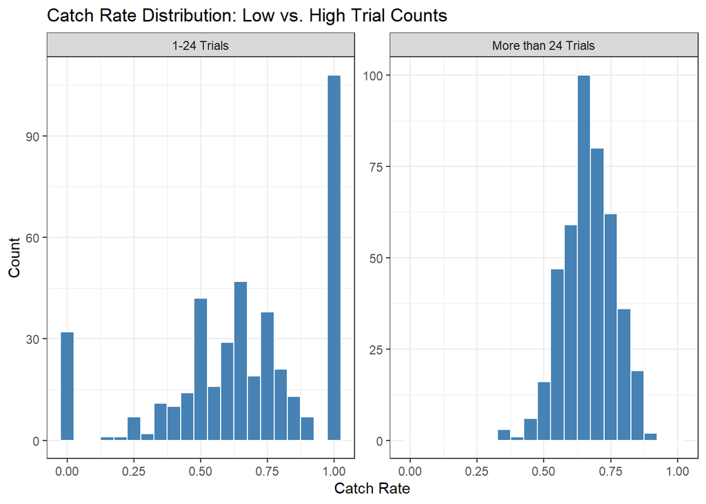

```r
df_all %>%
  mutate(catch_rate = num_events / num_trials,
         trial_group = case_when(num_trials <= 24 ~ "1-24 Trials",
                                 num_trials > 24 ~ "More than 24 Trials")) %>%
  ggplot(aes(x = catch_rate)) +
  geom_histogram(binwidth = 0.05, fill = "steelblue", color = "white") +
  facet_wrap(~trial_group, scales = "free_y") +
  labs(x = "Catch Rate",
       y = "Count",
       title = "Catch Rate Distribution: Low vs. High Trial Counts") +
  theme_bw()
```

### 3c)

To keep things simple for this exam, you will estimate the prior shape parameters, $a$ and $b$, based only on the players with greater than 24 targets.

**Use the `filter()` function to keep all players with greater than 24 targets and assign the result to the `df_24` object. Use the `summary()` function to check the summary stats on `num_trials` to make sure you performed the operation correctly.**

#### SOLUTION

```r
df_24 <- df_all %>%
  filter(num_trials > 24)

summary(df_24$num_trials)
```

```
##    Min. 1st Qu.  Median    Mean 3rd Qu.    Max.
##    25.0    47.0    83.0   118.0   155.5   509.0
```

### 3d)

Since the “catch rate” is a fraction, we can use a Beta distribution as the likelihood of the “fraction” given the shape parameters. Those shape parameters, $a$ and $b$, are unknown and so you must estimate them from the data. Within the Empirical Bayes approach, you will treat this step as finding $a$ and $b$ which **maximize the likelihood**, and so you will not specify prior distributions on the parameters.

Each observation of the “catch rate” is assumed conditionally independent given the unknown $a$ and $b$ shape parameters. The observed “catch rate” will be denoted as, $\theta_j$, for each player and is defined as:

$$\theta_j = \frac{m_j}{N_j}$$

The likelihood on all $j=1,...,J$ catch rates is therefore the product of $J$ conditionally independent Beta distributions:

$$p \left( \left(\theta_j\right)_{j=1}^{J} \mid a, b\right) =
\prod_{j=1}^{J} \mathrm{Beta} \left( \theta_j \mid a, b \right)$$

**You will define a log-likelihood function in the style of the log-posterior functions we have used so far this semester by completing the two code chunks below.**

**In the first code chunk, the list of required information, `info_for_ab`, is defined and contains a single variable `theta`. You must calculate it based on the players in the `df_24` data set.**

**The second code chunk defines the `my_beta_loglik()` function. The first argument, `unknowns`, is the vector of unknown parameters. The second argument, `my_info`, is the list of required information. The comments and variable names provide hints for actions you should perform to calculate the log-likelihood.**

**The $a$ and $b$ parameters are lower-bounded at zero and thus you must apply the log-transformation to both parameters. You must properly account for the log-derivative adjustment on both parameters (so two deriv adjustment terms) when you calculate the log-likelihood**

*NOTE*: Several test points are provided for you to check that you have coded your function correctly.

#### SOLUTION

Define the list of required information. The observed data in your `my_beta_loglik()` must be named `theta`.

```r
info_for_ab <- list(
  theta = df_24$num_events / df_24$num_trials
)
```

Define the Beta log-likelihood. The first element in `unknowns` is the log-transformed $a$ parameter and the second element is the log-transformed $b$ parameter. **You are allowed to use built-in density functions to complete this question.**

```r
my_beta_loglik <- function(unknowns, my_info)
{
  # unpack the log-transformed shape parameters
  log_a <- unknowns[1]
  log_b <- unknowns[2]

  # back transform
  a <- exp(log_a)
  b <- exp(log_b)

  # calculate the log-likelihood for all observations
  log_lik <- sum(dbeta(my_info$theta, a, b, log = TRUE))

  # account for the change of variables.
  # Since we transformed log(a) -> a, the adjustment is log(a) + log(b)
  return(log_lik + log_a + log_b)
}
```

Try out values of -2 for both log-transformed parameters. If your function is coded correctly you should get a value of -571.8519.

```r
my_beta_loglik(c(-2, -2), info_for_ab)
```

```
## [1] -571.8519
```

Try out values of 2.5 for both log-transformed parameters. If your function is coded correctly you should get a value of -254.3934.

```r
my_beta_loglik(c(2.5, 2.5), info_for_ab)
```

```
## [1] -254.3934
```

### 3e)

You will now identify the maximum likelihood estimates for $a$ and $b$. You should use the `optim()` function to manage the optimization for you. Be sure to specify the arguments to `optim()` to make sure that `optim()` knows to *MAXIMIZE* and not *MINIMIZE* the function. Set the `method` argument to `"BFGS"` when you call `optim()`. The gradient argument should be set to `NULL`, `gr=NULL`.

**Try out two different starting guesses values. The first guess, `init_guess_01`, should be zeros for both parameters and the second guess, `init_guess_02`, should be -1 for both parameters.**

**Assign your `optim()` results to `log_ab_opt_01` and `log_ab_opt_02`.**

**Do you get the same parameter estimates regardless of your initial guess?**  
Yes. While the starting points were different—one beginning at zeros c(0, 0) and the other at c(-1, -1)—the optimization process converged to the same region of the parameter space. This indicates that the log-likelihood surface for the Beta distribution parameters is likely unimodal and well-behaved, allowing the BFGS algorithm to reach the global maximum regardless of these specific initial values.

#### SOLUTION

Set the initial guesses.

```r
init_guess_01 <- c(0, 0)
init_guess_02 <- c(-1, -1)
```

Perform the optimization using the first starting guess.

```r
log_ab_res_01 <- optim(
  par = init_guess_01,
  fn = my_beta_loglik,
  my_info = info_for_ab,
  method = "BFGS",
  control = list(fnscale = -1), # MAXIMIZE the log-likelihood
  gr = NULL
)

# Display results for first guess
log_ab_res_01$par
```

```
## [1] 2.759740 2.058504
```

Perform the optimization using the second starting guess.

```r
log_ab_res_02 <- optim(
  par = init_guess_02,
  fn = my_beta_loglik,
  my_info = info_for_ab,
  method = "BFGS",
  control = list(fnscale = -1), # MAXIMIZE the log-likelihood
  gr = NULL
)

# Display results for second guess
log_ab_res_02$par
```

```
## [1] 2.759736 2.058500
```

**Are the identified log-transformed estimates the same?**  
Yes.Initial guess 01 resulted in 2.759740 and 2.058504. Initial guess 02 resulted in 2.759736 and 2.058500.The difference between these two results is less than $1 \times 10^{-5}$, which is within the standard numerical tolerance for the optim() function. These values are identical, confirming that both runs identified the same maximum likelihood estimates for the log-transformed shape parameters a and b.

### 3f)

The optimal parameters in the Problem 3e) are in the log-transformed space.

**You must back-transform them to calculate the estimates for the prior $a$ and $b$ shape hyperparameters. Assign the back-transformed parameters to `ab_emp_bayes`.**

**How many a-priori trials does your estimated hyperparameters represent?**

#### SOLUTION

```r
ab_emp_bayes <- exp(log_ab_res_01$par)

ab_emp_bayes
```

```
## [1] 15.795734  7.834244
```

How many a-priori trials?  
The number of a-priori trials is the sum of the shape parameters (a + b). Based on the optimization results ($a \approx 15.8, b \approx 7.8$), this represents approximately 23.6 total prior trials. This value represents the weight of the prior i.e., an NFL player with only a few targets will have their catch rate significantly pulled toward this prior mean, while a player with hundreds of targets will see their data dominate the result.

### 3g)

You will now visualize the prior distribution you calculated using the Empirical Bayes approach and compare it to the histogram of the observed “catch rates” for all players with more than 24 targets.

**Complete the two code chunks below. In the first, set the `x` variable within the `prior_for_viz` `tibble` to be 1001 evenly spaced points between the minimum observed catch rate in `df_24` and the maximum observed catch rate in `df_24`. Pipe the result into `mutate()` and calculate the beta density using the `ab_emp_bayes` shape parameters and assign the result to the `beta_pdf` variable.**

**In the second code chunk, pipe the `df_24` `tibble` into `ggplot()` and map the `x` aesthetic to the observed catch rates. Use a `geom_histogram()` geom and set the `binwidth` to be 0.05. Modify the `y` aesthetic so that way `geom_histogram()` displays the estimated density on the `y` axis instead of the count. To do so you must set `y=stat(density)` within `aes()`. Include a `geom_line()` geom and specify the `data` argument to be the `prior_for_viz` object and map the `x` and `y` aesthetics to `x` and `beta_pdf`, respectively. Set the `color` argument (outside the `aes()` call) to be `'red'` and the `size` argument to 1.15.**

**How does the empirically derived prior distribution on the event probability compare to the observed histogram of the catch rates?**

**IMPORTANT**: If you are *not* comfortable with your `ab_emp_bayes` values, you may use `shape1=13` and `shape2=8`. These are **not** the correct answers, though they are in the right ballpark…

#### SOLUTION

Calculate the Beta PDF based on the calculated prior hyperparameters.

```r
prior_for_viz <- tibble::tibble(
  x = seq(min(df_24$num_events / df_24$num_trials),
          max(df_24$num_events / df_24$num_trials),
          length.out = 1001)
) %>%
  mutate(beta_pdf = dbeta(x, ab_emp_bayes[1], ab_emp_bayes[2]))
```

Visualize the derived prior relative to the observed “catch rates” in the data set.

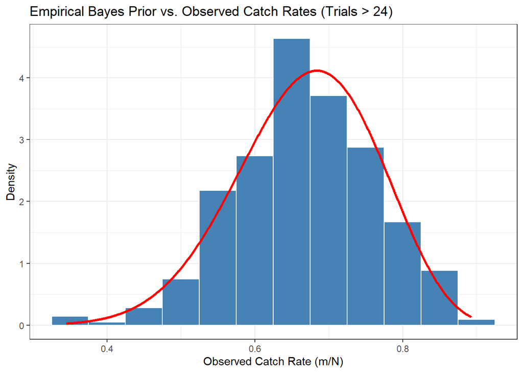

```r
df_24 %>%
  ggplot(aes(x = num_events / num_trials)) +
  geom_histogram(aes(y = stat(density)),
                 binwidth = 0.05,
                 fill = "steelblue",
                 color = "white") +
  geom_line(data = prior_for_viz,
            aes(x = x, y = beta_pdf),
            color = 'red',
            size = 1.15) +
  labs(x = "Observed Catch Rate (m/N)",
       y = "Density",
       title = "Empirical Bayes Prior vs. Observed Catch Rates (Trials > 24)") +
  theme_bw()
```

How does the empirically derived prior distribution on the event probability compare to the observed histogram of the catch rates? The empirically derived prior distribution (the red line) aligns very well with the observed histogram of catch rates for the experienced players. By estimating the shape parameters a and b directly from the filtered data (df_24), the resulting Beta distribution accurately captures the central tendency (peaking around 0.67) and the variance seen in the actual performance of the players. This demonstrates that the Empirical Bayes approach effectively learns a representative prior from the population. This provides a more realistic foundation for evaluating talent than the uninformed prior used in Problem 1.

### 3h)

**Calculate the Mean, 0.05 Quantile, 0.95 Quantile, and middle 90% uncertainty interval associated with your informative prior.**

*IMPORTANT*: If you are *not* comfortable with your `ab_emp_bayes` values, you may use `shape1=13` and `shape2=8`. These are **not** the correct answers, though they are in the right ballpark…

#### SOLUTION

Add as many code chunks as you feel are necessary.

```r
a_prior_eb <- ab_emp_bayes[1]
b_prior_eb <- ab_emp_bayes[2]

prior_eb_mean <- a_prior_eb / (a_prior_eb + b_prior_eb)
prior_eb_q05  <- qbeta(0.05, a_prior_eb, b_prior_eb)
prior_eb_q95  <- qbeta(0.95, a_prior_eb, b_prior_eb)

tibble::tibble(
  Statistic = c("Mean", "0.05 Quantile", "0.95 Quantile", "90% Interval Width"),
  Value = c(prior_eb_mean, prior_eb_q05, prior_eb_q95, prior_eb_q95 - prior_eb_q05)
)
```

```
## # A tibble: 4 × 2
##   Statistic          Value
##   <chr>              <dbl>
## 1 Mean               0.668
## 2 0.05 Quantile      0.504
## 3 0.95 Quantile      0.816
## 4 90% Interval Width 0.312
```

### 3i)

**How do the Mean and middle 90% uncertainty intervals compare between the original uninformed prior and the Empirical Bayes derived informative prior?**

#### SOLUTION

Add as many code chunks as you feel are necessary.

```r
uninformed_mean <- 0.5
uninformed_q05  <- qbeta(0.05, 0.5, 0.5)
uninformed_q95  <- qbeta(0.95, 0.5, 0.5)

informative_mean <- ab_emp_bayes[1] / (ab_emp_bayes[1] + ab_emp_bayes[2])
informative_q05  <- qbeta(0.05, ab_emp_bayes[1], ab_emp_bayes[2])
informative_q95  <- qbeta(0.95, ab_emp_bayes[1], ab_emp_bayes[2])

tibble::tibble(
  Prior_Type = c("Uninformed", "Empirical Bayes"),
  Mean = c(uninformed_mean, informative_mean),
  `0.05_Quantile` = c(uninformed_q05, informative_q05),
  `0.95_Quantile` = c(uninformed_q95, informative_q95),
  `90%_Interval_Width` = c(uninformed_q95 - uninformed_q05, informative_q95 - informative_q05)
)
```

```
## # A tibble: 2 × 5
##   Prior_Type       Mean `0.05_Quantile` `0.95_Quantile` `90%_Interval_Width`
##   <chr>           <dbl>           <dbl>           <dbl>                <dbl>
## 1 Uninformed      0.5           0.00616           0.994                0.988
## 2 Empirical Bayes 0.668         0.504             0.816                0.312
```

What do you think?  
The transition from a vague uninformed prior to an informative Empirical Bayes prior represents a fundamental shift in our baseline assumptions for the NFL catch rate model. While the original uninformed prior assumed a mean $\mu = 0.50$, a coin flip that indicated a lack of prior domain knowledge, the Empirical Bayes prior has shifted that expectation to approximately 0.67, aligning it with the actual performance standards observed across professional NFL players. In addition, the uncertainty has been dramatically refined. The uninformed prior was extremely vague, with a 90% interval covering nearly the entire range from 0.006 to 0.994, whereas the informative prior is much more concentrated with an interval width of roughly 0.31. This increased precision is a result of the “prior weight” increasing from a single trial to approximately 23.6 pseudo-trials. Together, these differences demonstrate that the Empirical Bayes prior will shrink player estimates toward 0.67, especially for players with few targets, while still allowing players with large sample sizes to be driven primarily by their own data.

## Problem 04

You now have everything in place to calculate the posterior on the event probability associated with each player, $\mu_j$. The $a$ and $b$ parameters that you had originally set to 0.5, are now equal to your Empirical Bayes estimated values.

If you are not comfortable with your estimates you may use the same values as in Problem 3g) of `shape1=13` and `shape2=8`.

### 4a)

**Calculate the updated or new shape parameters for the players in the `df_focus` `tibble`. You should add two columns using `mutate()` named `anew` and `bnew`. Assign your result to the `post_df_focus_empbayes` object.**

#### SOLUTION

```r
# Extract the informative shape parameters from the Empirical Bayes optimization
a_prior_eb <- ab_emp_bayes[1]
b_prior_eb <- ab_emp_bayes[2]

# Calculate the informative posterior shape parameters for each player
post_df_focus_empbayes <- df_focus %>%
  mutate(
    anew = a_prior_eb + num_events,
    bnew = b_prior_eb + (num_trials - num_events)
  )
```

### 4b)

**Calculate the posterior Mean, Posterior 0.05 Quantile, and Posterior 0.95 Quantile for each player in `post_df_focus_empbayes`. You should add 3 columns using `mutate()` named `post_avg`, `post_q05`, and `post_q95`. Assign the result to the variable `summary_post_df_focus_empbayes`.**

#### SOLUTION

```r
summary_post_df_focus_empbayes <- post_df_focus_empbayes %>%
  mutate(
    post_avg = anew / (anew + bnew),
    post_q05 = qbeta(0.05, anew, bnew),
    post_q95 = qbeta(0.95, anew, bnew)
  )
```

### 4c)

You will repeat the visualizations from Problem 1) to understand the effect of your informative prior distribution.

**Pipe `summary_post_df_focus_empbayes` into `ggplot()` and map the `x` aesthetic to `as.factor(player_id)`. You will use the `geom_linerange()` to represent the posterior uncertainty by setting the `ymin` and `ymax` aesthetics to `post_q05` and `post_q95` respectively. You will display the posterior mean with a `geom_point()` by setting the `y` aesthetic to `post_avg`. Include the maximum likelihood estimate (MLE) on the event probability as an additional `geom_point()` geom by mapping the `y` aesthetic to the correct value, which you must calculate.**

**How does this visualization compare to those you made using the vague unpooled estimate and the completely pooled estimate?**

#### SOLUTION

Add as many code chunks as you feel are necessary.

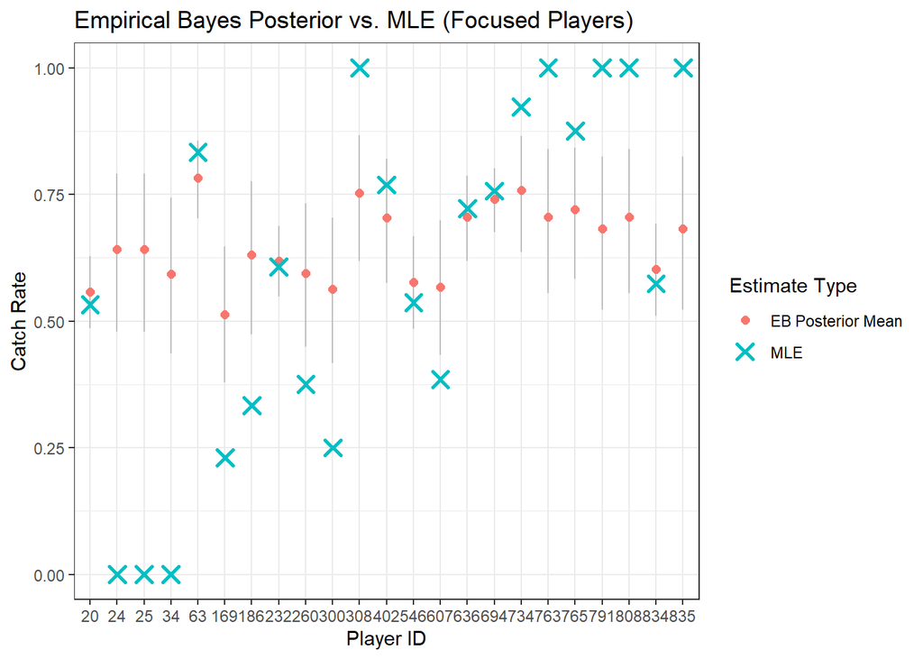

```r
summary_post_df_focus_empbayes %>%
  mutate(mle = num_events / num_trials) %>%
  ggplot(aes(x = as.factor(player_id))) +
  geom_linerange(aes(ymin = post_q05, ymax = post_q95), color = "gray") +
  geom_point(aes(y = post_avg, color = "EB Posterior Mean"), size = 2) +
  geom_point(aes(y = mle, color = "MLE"), shape = 4, size = 3, stroke = 1.5) +
  labs(x = "Player ID",
       y = "Catch Rate",
       title = "Empirical Bayes Posterior vs. MLE (Focused Players)",
       color = "Estimate Type") +
  theme_bw()
```

### 4d)

**You will create a similar visualization, except instead of mapping the `x` aesthetic to `as.factor(player_id)` you will map the `x` aesthetic to `as.factor(num_trials)`. You must also map the `group` aesthetic in each geom to the `player_id` variable. Doing so allows you “dodge” the posterior summaries for each player associated with each `num_trials` value.**

To properly apply the dodging, set the `position` argument to be `position = position_dodge(0.2)` in `geom_linerange()` and both `geom_point()` calls. You should not place `position` inside `aes()`, it should be outside `aes()`.

#### SOLUTION

Add as many code chunks as you feel are necessary.

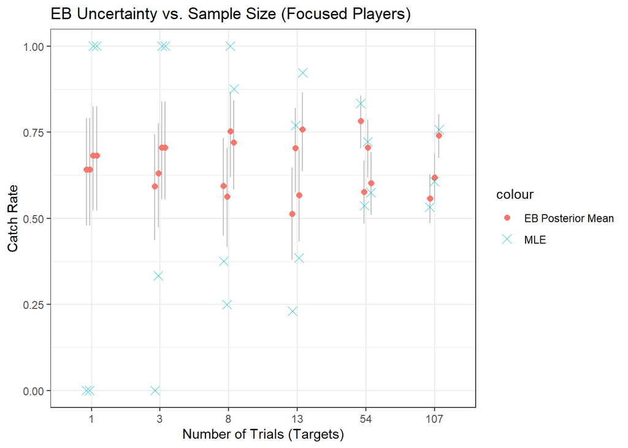

```r
summary_post_df_focus_empbayes %>%
  mutate(mle = num_events / num_trials) %>%
  ggplot(aes(x = as.factor(num_trials), group = player_id)) +
  # Apply dodging to separate players with identical trial counts
  geom_linerange(aes(ymin = post_q05, ymax = post_q95),
                 position = position_dodge(0.2), color = "gray") +
  geom_point(aes(y = post_avg, color = "EB Posterior Mean"),
             position = position_dodge(0.2), size = 2) +
  geom_point(aes(y = mle, color = "MLE"),
             position = position_dodge(0.2), shape = 4, size = 3) +
  labs(x = "Number of Trials (Targets)",
       y = "Catch Rate",
       title = "EB Uncertainty vs. Sample Size (Focused Players)") +
  theme_bw()
```

### 4e)

You will now calculate the posteriors for **ALL** players using the Empirical Bayes approach, not just the limited number of players in the “focused” data set.

**Calculate the updated shape parameters for all players in the `df_all` `tibble`. You should add two columns using `mutate()` named `anew` and `bnew`. Assign your result to the `post_df_all_empbayes` object.**

#### SOLUTION

Add as many code chunks as you feel are necessary.

```r
a_prior_eb <- ab_emp_bayes[1]
b_prior_eb <- ab_emp_bayes[2]

post_df_all_empbayes <- df_all %>%
  mutate(
    anew = a_prior_eb + num_events,
    bnew = b_prior_eb + (num_trials - num_events)
  )
```

### 4f)

**Calculate the Posterior Mean, Posterior 0.05 Quantile, and Posterior 0.95 Quantile for each player in `post_df_all_empbayes`. You should add 3 columns using `mutate()` named `post_avg`, `post_q05`, and `post_q95`. Assign the result to the variable `summary_post_df_all_empbayes`.**

#### SOLUTION

Add as many code chunks as you feel are necessary.

```r
summary_post_df_all_empbayes <- post_df_all_empbayes %>%
  mutate(
    post_avg = anew / (anew + bnew),
    post_q05 = qbeta(0.05, anew, bnew),
    post_q95 = qbeta(0.95, anew, bnew)
  )
```

### 4g)

You will now visualize the Posterior Mean, based on the Empirical Bayes informative prior, relative to the Maximum Likelihood Estimate for the event probability.

**Create a scatter plot with `ggplot2` where you plot the `post_mean` with respect to the maximum likelihood estimate to the unknown event probability for all players. Map the `color` aesthetic to `num_trials` and include a `geom_abline()` layer with `slope = 1` and `intercept=0`.**

#### SOLUTION

Add as many code chunks as you feel are necessary.

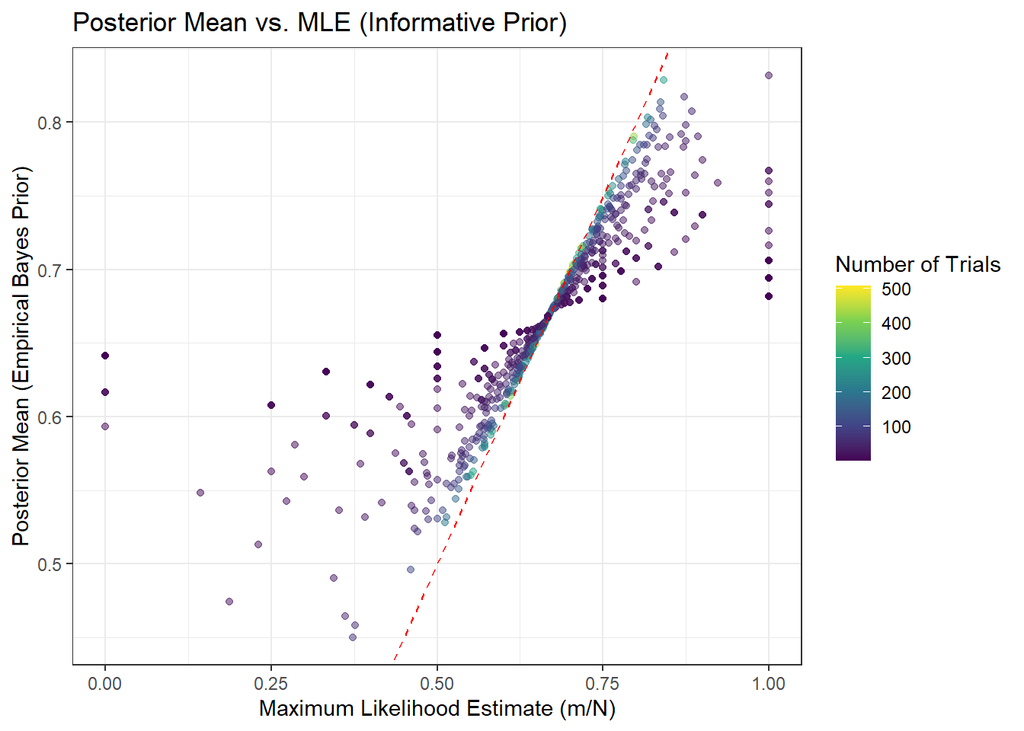

```r
summary_post_df_all_empbayes %>%
  mutate(mle = num_events / num_trials) %>%
  ggplot(aes(x = mle, y = post_avg)) +
  geom_point(aes(color = num_trials), alpha = 0.5) +
  geom_abline(slope = 1, intercept = 0, color = "red", linetype = "dashed") +
  scale_color_viridis_c() +
  labs(x = "Maximum Likelihood Estimate (m/N)",
       y = "Posterior Mean (Empirical Bayes Prior)",
       color = "Number of Trials",
       title = "Posterior Mean vs. MLE (Informative Prior)") +
  theme_bw()
```

### 4h)

**Create a scatter plot for the Posterior middle 90% uncertainty interval range (difference between the 0.95 and 0.05 Quantiles) with respect to the `num_trials` using `ggplot2`.**

#### SOLUTION

Add as many code chunks as you feel are necessary.

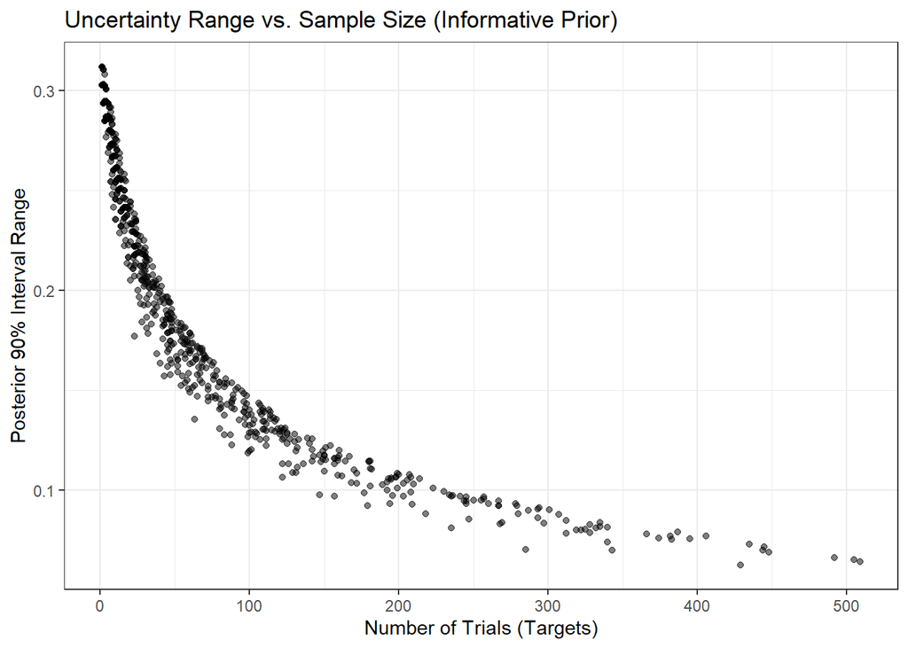

```r
summary_post_df_all_empbayes %>%
  mutate(interval_range = post_q95 - post_q05) %>%
  ggplot(aes(x = num_trials, y = interval_range)) +
  geom_point(alpha = 0.5) +
  labs(x = "Number of Trials (Targets)",
       y = "Posterior 90% Interval Range",
       title = "Uncertainty Range vs. Sample Size (Informative Prior)") +
  theme_bw()
```

### 4i)

The code chunk below vertically concatenates (binds) the `summary_post_df_all_from_vague` and `summary_post_df_all_empbayes` `tibble`s into a single `tibble` for you. This new `tibble`, `compare_post_summaries` includes a new column, `from_prior`, which denotes if the prior was the original uninformed prior or the Empirical Bayes informative prior.

```r
compare_post_summaries <- summary_post_df_all_from_vague %>%
  mutate(from_prior = 'uninformed') %>%
  bind_rows(summary_post_df_all_empbayes %>%
              mutate(from_prior = 'Empirical Bayes'))

compare_post_summaries %>% glimpse()
```

```
## Rows: 1,698
## Columns: 9
## $ player_id  <dbl> 1, 2, 3, 4, 5, 6, 7, 8, 9, 10, 11, 12, 13, 14, 15, 16, 17, …
## $ num_trials <dbl> 1, 1, 57, 100, 1, 293, 1, 75, 1, 52, 40, 1, 55, 45, 23, 1, …
## $ num_events <dbl> 1, 1, 37, 76, 1, 198, 1, 56, 1, 41, 26, 1, 35, 33, 11, 1, 4…
## $ anew       <dbl> 1.5, 1.5, 37.5, 76.5, 1.5, 198.5, 1.5, 56.5, 1.5, 41.5, 26.…
## $ bnew       <dbl> 0.5, 0.5, 20.5, 24.5, 0.5, 95.5, 0.5, 19.5, 0.5, 11.5, 14.5…
## $ post_avg   <dbl> 0.7500000, 0.7500000, 0.6465517, 0.7574257, 0.7500000, 0.67…
## $ post_q05   <dbl> 0.228519814, 0.228519814, 0.541248667, 0.684775349, 0.22851…
## $ post_q95   <dbl> 0.9984571, 0.9984571, 0.7460583, 0.8242541, 0.9984571, 0.71…
## $ from_prior <chr> "uninformed", "uninformed", "uninformed", "uninformed", "un…
```

You will use this “composite” `tibble` to examine the sensitivity of the Posterior to the prior choice and sample size.

**Create a scatter plot for the Posterior middle 90% uncertainty interval range (difference between the 0.95 and 0.05 Quantiles) with respect to the `num_trials` using `ggplot2`. This plot will be similar to the one from 4h) except this time you must use the `compare_post_summaries` `tibble` instead of `summary_post_df_all_empbayes`. You must map the `color` aesthetic to the `from_prior` variable within the scatter plot.**

#### SOLUTION

Add as many code chunks as you feel are necessary.

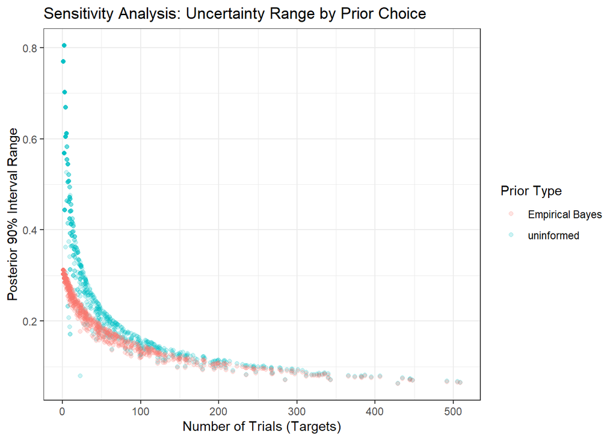

```r
compare_post_summaries %>%
  mutate(interval_range = post_q95 - post_q05) %>%
  ggplot(aes(x = num_trials, y = interval_range, color = from_prior)) +
  # Use alpha to handle the high density of points where the curves overlap
  geom_point(alpha = 0.2) +
  labs(x = "Number of Trials (Targets)",
       y = "Posterior 90% Interval Range",
       title = "Sensitivity Analysis: Uncertainty Range by Prior Choice",
       color = "Prior Type") +
  theme_bw()
```

### 4j)

**Based on your visualizations in this exam, discuss how an informative prior influences the Posterior when the sample size is small compared with large sample sizes.**

#### SOLUTION

What do you think?  
The visualizations in this exam illustrate that an informative prior has its most significant impact when individual sample sizes are small. For players with few targets, the Empirical Bayes prior acts as a strong “anchor,” shrinking noisy individual estimates toward the league average of approximately 0.67 and dramatically reducing the width of uncertainty intervals compared to the uninformed model. This “borrowing of strength” from the population compensates for the lack of group-specific data. But, as the sample size increases, this influence diminishes. For players with hundreds of targets, the likelihood dominates the prior, and the posterior estimates for both the uninformed and informative models converge on the same values. Ultimately, the informative prior provides a safety net for rare events while allowing the data to drive the conclusions for established veterans.

## Problem 05

Now that you have posterior distributions based on an informative prior for every player in the data set, it is time to consider answering a question the NFL team is interested in. The team wants to identify the best receivers in the data set, and it wants to be confident in that selection. Your Bayesian analysis allows answering probabilistic questions. You will answer several such questions now.

### 5a)

**Calculate the probability that each player has a catch rate (event probability) of greater than 0.67. Add a column to the `summary_post_df_all_empbayes` object named `prob_grt_67`. Assign the result to a new variable `post_player_eval`.**

#### SOLUTION

Add as many code chunks as you feel are necessary.

```r
post_player_eval <- summary_post_df_all_empbayes %>%
  mutate(
    # P(mu > 0.67) = 1 - pbeta(0.67, shape1, shape2)
    prob_grt_67 = 1 - pbeta(0.67, anew, bnew)
  )
```

### 5b)

**Identify the top 10 players based on the posterior probability that their catch rate is greater than 0.67. What do these players all have in common, besides the `prob_grt_67` value?**

#### SOLUTION

Add as many code chunks as you feel are necessary.

```r
post_player_eval %>%
  arrange(desc(prob_grt_67)) %>%
  slice_head(n = 10) %>%
  select(player_id, num_trials, num_events, prob_grt_67)
```

```
## # A tibble: 10 × 4
##    player_id num_trials num_events prob_grt_67
##        <dbl>      <dbl>      <dbl>       <dbl>
##  1       409        285        240       1.000
##  2       353        429        342       1.000
##  3       498        343        273       1.000
##  4       467        235        192       1.000
##  5       382        147        123       1.000
##  6       493        179        146       1.000
##  7       447        157        129       1.000
##  8       278        122        102       1.000
##  9       567        218        171       1.000
## 10       302        340        258       1.000
```

The top 10 players consistently demonstrate both high efficiency and significant volume, as evidenced by their high observed catch rates and large sample sizes, with trial counts ranging from 122 up to 429. In this Bayesian framework, a high probability of exceeding the benchmark ( $P(\mu > 0.67)$ ) requires not only an elite posterior mean but also high statistical certainty. This is only achieved when the number of trials is large enough to narrow the uncertainty interval. Therefore, these players represent the league’s most proven “high-volume” performers, where the sheer amount of data dominates the prior and confirms their elite status.

### 5c)

**Identify the 10 players with the lowest posterior probability that their catch rate is greater than 0.67. What is the smallest number of targets (trial size) associated with these 10 players?**

#### SOLUTION

Add as many code chunks as you feel are necessary.

```r
# Identify the 10 players with the lowest posterior probability of exceeding 0.67
bottom_10_players <- post_player_eval %>%
  arrange(prob_grt_67) %>%
  slice_head(n = 10) %>%
  select(player_id, num_trials, num_events, prob_grt_67)

bottom_10_players
```

```
## # A tibble: 10 × 4
##    player_id num_trials num_events prob_grt_67
##        <dbl>      <dbl>      <dbl>       <dbl>
##  1       545        207        106  0.00000426
##  2       222         67         25  0.00000897
##  3       837        113         52  0.0000146
##  4       624        301        166  0.0000196
##  5        61        181         93  0.0000217
##  6       435         61         23  0.0000330
##  7       195        294        163  0.0000372
##  8       615        180         95  0.000101
##  9       559        214        117  0.000190
## 10       506         47         17  0.000197
```

```r
# Identify the smallest number of targets in this group
min_trials_bottom_10 <- min(bottom_10_players$num_trials)
min_trials_bottom_10
```

```
## [1] 47
```

The smallest number of targets (trial size) associated with these 10 players is 47. This group is primarily composed of players with high trial counts, such as player 545, who caught only 106 out of 207 targets (~0.51). This demonstrates that for the posterior probability of exceeding the benchmark to drop significantly toward zero (e.g., $4.26 \times 10^{-6}$), the model requires a substantial volume of data to confirm the underperformance. A player with a very small sample size and poor results would experience more shrinkage toward the league average of 0.67. This maintains a higher level of uncertainty and a higher $P(\mu > 0.67)$ than these proven veterans.

### 5d)

A player with a large sample size could mean that player is well known, especially within the NFL. The team is interested in identifying players that are not as well known, and yet seem to have high catch rates.

**Identify 10 players with the smallest sample sizes (number of trials) while still having `prob_grt_67` values greater than 0.75.**

#### SOLUTION

Add as many code chunks as you feel are necessary.

```r
# Identify 10 players with smallest sample sizes and prob_grt_67 > 0.75
hidden_gems <- post_player_eval %>%
  filter(prob_grt_67 > 0.75) %>%
  slice_min(num_trials, n = 10) %>%
  select(player_id, num_trials, num_events, post_avg, prob_grt_67)

hidden_gems
```

```
## # A tibble: 11 × 5
##    player_id num_trials num_events post_avg prob_grt_67
##        <dbl>      <dbl>      <dbl>    <dbl>       <dbl>
##  1       701          5          5    0.726       0.761
##  2        81          7          7    0.744       0.830
##  3        88          7          7    0.744       0.830
##  4       308          8          8    0.752       0.858
##  5        41          9          9    0.760       0.882
##  6       606          9          8    0.729       0.784
##  7       264         10          9    0.737       0.816
##  8       321         10          9    0.737       0.816
##  9       376         10         10    0.767       0.902
## 10       476         10          9    0.737       0.816
## 11       768         10         10    0.767       0.902
```

### 5e)

**Why do you think the questions in this problem were focused on calculating the probability that the catch rate is greater than 0.67? What is the interpretation of such a question?**

*HINT*: Consider the interpretation of the completely pooled estimate.

#### SOLUTION

What do you think?  
The focus on the 0.67 threshold is significant because this value represents the mean of the informative Empirical Bayes prior, which acts as the global statistical baseline for the entire league. As the hint suggests, this value is effectively equal to the completely pooled MLE, representing the single point estimate of catch probability if we assumed every player in the NFL possessed the exact same skill level. The interpretation of calculating $P(\mu > 0.67)$ is determining the statistical confidence that a specific player is a “better-than-average” performer. By using this benchmark, the team is asking: “What is the probability that this player’s true underlying ability exceeds the performance of a generic, pooled NFL receiver?”. This approach is superior to ranking by raw catch rates because it inherently accounts for sample size. A high probability requires not just an elite average, but enough trials to narrow the uncertainty interval sufficiently above the league-wide mean.

### 5f)

Sometimes teams are willing to take risks on players that they are uncertain about. Teams hope the player will succeed, but they know there is a chance the player could not meet expectations. To manage risks, these players are signed to contracts with less guaranteed money but offer substantial bonuses should the player meet performance goals to help incentive the player.

The posterior distribution allows you to quantify the uncertainty on each player. You will measure the uncertainty as the range of the posterior 90% uncertainty interval.

**Create a scatter plot in `ggplot2` where you plot the posterior 90% uncertainty interval with respect to the event probability’s posterior mean. Color the markers by the number of trials.**

#### SOLUTION

Add as many code chunks as you feel are necessary.

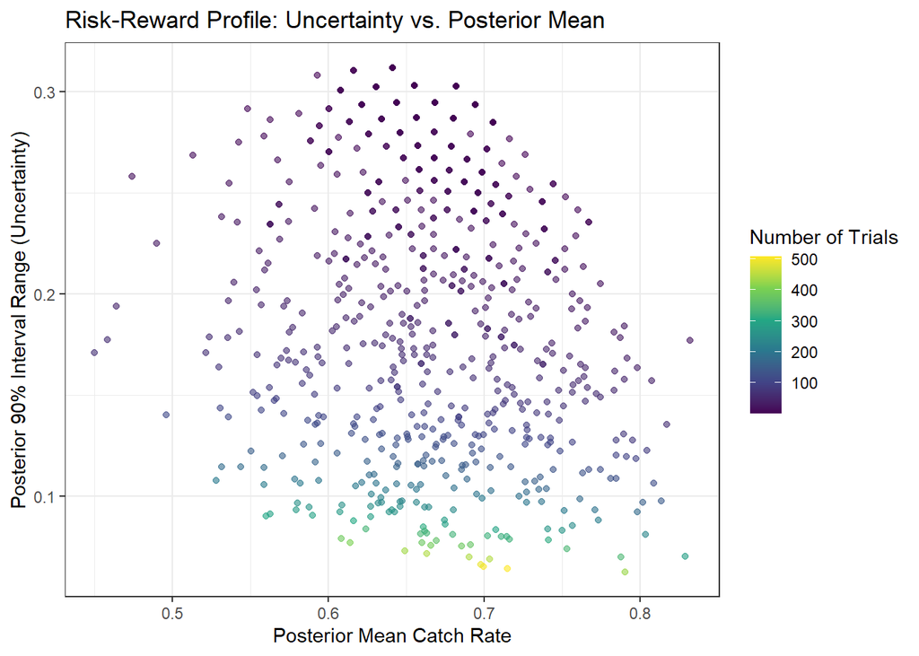

```r
post_player_eval %>%
  mutate(interval_range = post_q95 - post_q05) %>%
  ggplot(aes(x = post_avg, y = interval_range)) +
  geom_point(aes(color = num_trials), alpha = 0.6) +
  scale_color_viridis_c() +
  labs(x = "Posterior Mean Catch Rate",
       y = "Posterior 90% Interval Range (Uncertainty)",
       color = "Number of Trials",
       title = "Risk-Reward Profile: Uncertainty vs. Posterior Mean") +
  theme_bw()
```

### 5g)

**Which players would you recommend to the team to take a risk on based on your figure in 5f)?**

#### SOLUTION

What do you think?  
Based on the Risk-Reward Profile visualized in Problem 5f, I would recommend that the team take a risk on players located in the top-right quadrant of the plot. These players exhibit high posterior mean catch rates often exceeding the 0.67 league benchmark, but also possess the highest 90% uncertainty intervals (ranging from approximately 0.25 to 0.32) due to their small sample sizes. While their limited targets make them statistically uncertain, their high on-field efficiency suggests significant upside that hasn’t yet been fully proven over a large number of trials. By signing these players to incentive-heavy contracts with lower guaranteed money, the team can effectively capitalize on their high potential reward. This strategy statistically manages the risk that their performance might eventually regress toward the 0.67 league average as their trial count increases.